# CIFAR-10 Image Classification using CNN (PyTorch)

### CO7113 AI for Space - Assignment 1

This notebook implement a Convolutional Neural Network (CNN) to classify images from the CIFAR-10 dataset using PyTorch. The CIFAR-10 dataset contain 60,000 color images of size 32x32 with 10 different classes.

**Notebook Structure:**

- **Part 1**: Build, train and test a Basic CNN classifier
- **Part 2**: Technical report - CNN structure, loss function, accuracy analysis
- **Part 3**: Research - Residual Connections and Batch Normalization

```python
# import all the libraries we need
import torch
import torch.nn as nn
import torch.optim as optim
import torchvision
import torchvision.transforms as transforms
import matplotlib.pyplot as plt
import numpy as np
import os
```

```python
# use GPU if available, this will speed up training a lot
device = torch.device('cuda' if torch.cuda.is_available() else 'cpu')
print("Using device:", device)

# fix random seed so results is reproducible every run
torch.manual_seed(42)
np.random.seed(42)

# data augmentation- these transform help model see more variety of images
# which make it generalize better to new images it never seen before
transform_train = transforms.Compose([
    transforms.RandomHorizontalFlip(),       # randomly flip image left to right
    transforms.RandomCrop(32, padding=4),    # randomly crop with 4 pixel padding
    transforms.ToTensor(),                   # convert PIL image to tensor [0,1]
    transforms.Normalize(
        mean=(0.4914, 0.4822, 0.4465),       # CIFAR-10 mean for each RGB channel
        std=(0.2023, 0.1994, 0.2010)         # CIFAR-10 std for each RGB channel
    )
])

# for test set we only normalize, no augmentation is done because we want real evaluation
transform_test = transforms.Compose([
    transforms.ToTensor(),
    transforms.Normalize(
        mean=(0.4914, 0.4822, 0.4465),
        std=(0.2023, 0.1994, 0.2010)
    )
])

# download CIFAR-10 dataset
print("\nLoading CIFAR-10 dataset...")
train_dataset = torchvision.datasets.CIFAR10(
    root='./data', train=True, download=True, transform=transform_train
)
test_dataset = torchvision.datasets.CIFAR10(
    root='./data', train=False, download=True, transform=transform_test
)

# creating data loaders because num_workers=0 to avoid multiprocessing issues on different OS
train_loader = torch.utils.data.DataLoader(
    train_dataset, batch_size=64, shuffle=True, num_workers=0
)
test_loader = torch.utils.data.DataLoader(
    test_dataset, batch_size=64, shuffle=False, num_workers=0
)

# class names for CIFAR-10
classes = ('airplane', 'automobile', 'bird', 'cat', 'deer',
           'dog', 'frog', 'horse', 'ship', 'truck')

print(f"Training samples  : {len(train_dataset)}")
print(f"Testing samples   : {len(test_dataset)}")
print(f"Number of classes : {len(classes)}")
print(f"Classes           : {classes}")
print(f"Batches in train  : {len(train_loader)}")
```

```
Using device: cuda

Loading CIFAR-10 dataset...
```

```
Training samples  : 50000
Testing samples   : 10000
Number of classes : 10
Classes           : ('airplane', 'automobile', 'bird', 'cat', 'deer', 'dog', 'frog', 'horse', 'ship', 'truck')
Batches in train  : 782
```

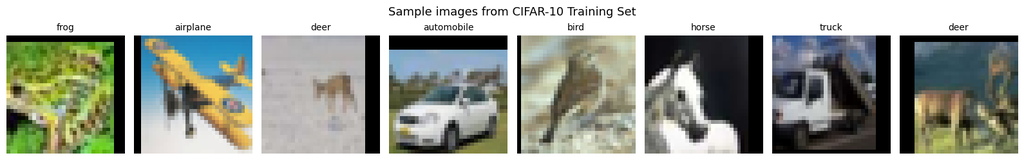

```python
# show some sample images so we know what the data look like
def show_sample_images(loader, classes, n=8):
    dataiter = iter(loader)
    images, labels = next(dataiter)

    fig, axes = plt.subplots(1, n, figsize=(16, 2.5))
    for i in range(n):
        img = images[i].clone()
        # unnormalize the image back so it look correct for display
        mean = torch.tensor([0.4914, 0.4822, 0.4465]).view(3, 1, 1)
        std  = torch.tensor([0.2023, 0.1994, 0.2010]).view(3, 1, 1)
        img = img * std + mean
        img = img.numpy().transpose(1, 2, 0)
        img = np.clip(img, 0, 1)
        axes[i].imshow(img)
        axes[i].set_title(classes[labels[i]], fontsize=10)
        axes[i].axis('off')

    plt.suptitle("Sample images from CIFAR-10 Training Set", fontsize=13)
    plt.tight_layout()
    plt.show()

show_sample_images(train_loader, classes)
```

## Part 1: Basic CNN Classifier

I build a simple CNN model with 3 convolutional blocks and 2 fully connected layers. Below is the justification for all the hyperparameter choices:

| Hyperparameter | Value | Justification |
| --- | --- | --- |
| Batch size | 64 | Good balance between speed and memory. Too large batch need more memory, too small batch make training slow and unstable. |
| Learning rate | 0.001 | Standard starting LR for Adam optimizer. Work well for most CNN tasks in practice. |
| Epochs | 20 | Give enough time for the model to converge and learn good features without too much overfitting. |
| Dropout | 0.4 | Drop 40% of neurons randomly during training to prevent overfitting by forcing network to not rely on specific neurons. |
| LR Scheduler | StepLR(step=7, gamma=0.5) | Reduce learning rate by half every 7 epochs. This help model fine-tune more carefully in later stage of training. |
| Optimizer | Adam | Adam is adaptive optimizer that adjust LR per parameter automatically, it work very well for CNN in practice. |

```python
# Define the Basic CNN classifier
class BasicCNN(nn.Module):
    def __init__(self):
        super(BasicCNN, self).__init__()

        # ---- Convolutional Layers ----
        # we increase channels at each stage: 32 -> 64 -> 128
        # this allow model to learn more complex features in deeper layers
        self.conv1 = nn.Conv2d(in_channels=3,  out_channels=32,  kernel_size=3, padding=1)
        self.conv2 = nn.Conv2d(in_channels=32, out_channels=64,  kernel_size=3, padding=1)
        self.conv3 = nn.Conv2d(in_channels=64, out_channels=128, kernel_size=3, padding=1)

        # max pooling reduce spatial size by 2 each time
        self.pool = nn.MaxPool2d(kernel_size=2, stride=2)

        # relu add non-linearity so model can learn complex patterns
        self.relu = nn.ReLU()

        # dropout for regularization - prevent overfitting
        self.dropout = nn.Dropout(p=0.4)

        # ---- Fully Connected Layers ----
        # image is 32x32, after 3 max pools: 32->16->8->4
        # flatten size = 128 channels * 4 * 4 = 2048
        self.fc1 = nn.Linear(128 * 4 * 4, 512)
        self.fc2 = nn.Linear(512, 10)   # 10 output for 10 classes

    def forward(self, x):
        # === Block 1 ===
        # input:  [batch, 3, 32, 32]
        x = self.pool(self.relu(self.conv1(x)))  # -> [batch, 32, 16, 16]

        # === Block 2 ===
        x = self.pool(self.relu(self.conv2(x)))  # -> [batch, 64,  8,  8]

        # === Block 3 ===
        x = self.pool(self.relu(self.conv3(x)))  # -> [batch, 128, 4,  4]

        # flatten for fully connected layers
        x = x.view(x.size(0), -1)               # -> [batch, 2048]

        # FC layers
        x = self.dropout(self.relu(self.fc1(x))) # -> [batch, 512]
        x = self.fc2(x)                           # -> [batch, 10]

        return x


# create model and move to device
basic_net = BasicCNN().to(device)
print("Basic CNN Model:")
print("=" * 50)
print(basic_net)
total_params = sum(p.numel() for p in basic_net.parameters())
print(f"\nTotal trainable parameters: {total_params:,}")
```

```
Basic CNN Model:
==================================================
BasicCNN(
  (conv1): Conv2d(3, 32, kernel_size=(3, 3), stride=(1, 1), padding=(1, 1))
  (conv2): Conv2d(32, 64, kernel_size=(3, 3), stride=(1, 1), padding=(1, 1))
  (conv3): Conv2d(64, 128, kernel_size=(3, 3), stride=(1, 1), padding=(1, 1))
  (pool): MaxPool2d(kernel_size=2, stride=2, padding=0, dilation=1, ceil_mode=False)
  (relu): ReLU()
  (dropout): Dropout(p=0.4, inplace=False)
  (fc1): Linear(in_features=2048, out_features=512, bias=True)
  (fc2): Linear(in_features=512, out_features=10, bias=True)
)

Total trainable parameters: 1,147,466
```

### Technical Report - Section 1: CNN Structure

The CNN model consist of **3 convolutional blocks** followed by **2 fully connected layers**. All conv layers use 3x3 kernel with padding=1 to keep spatial dimension same before pooling. MaxPool2d with stride=2 reduce each spatial dimension by half.

| Layer | Type | Input Shape | Output Shape | Parameters |
| --- | --- | --- | --- | --- |
| - | Input | [B, 3, 32, 32] | [B, 3, 32, 32] | 0 |
| conv1 | Conv2d(3→32, 3×3, pad=1) | [B, 3, 32, 32] | [B, 32, 32, 32] | 896 |
| relu + pool1 | ReLU + MaxPool2d(2,2) | [B, 32, 32, 32] | [B, 32, 16, 16] | 0 |
| conv2 | Conv2d(32→64, 3×3, pad=1) | [B, 32, 16, 16] | [B, 64, 16, 16] | 18,496 |
| relu + pool2 | ReLU + MaxPool2d(2,2) | [B, 64, 16, 16] | [B, 64, 8, 8] | 0 |
| conv3 | Conv2d(64→128, 3×3, pad=1) | [B, 64, 8, 8] | [B, 128, 8, 8] | 73,856 |
| relu + pool3 | ReLU + MaxPool2d(2,2) | [B, 128, 8, 8] | [B, 128, 4, 4] | 0 |
| Flatten | - | [B, 128, 4, 4] | [B, 2048] | 0 |
| fc1 + dropout | Linear(2048→512) + Dropout(0.4) | [B, 2048] | [B, 512] | 1,049,088 |
| fc2 | Linear(512→10) | [B, 512] | [B, 10] | 5,130 |

*(B = batch size)*

The number of channels increase at each stage 32 to 64 to 128 to allow the network to learn more complex and abstract feature at deeper layers. Early layers detect simple features like edges and colors, while deeper layers detect complex patterns like shapes and object parts. Dropout(0.4) is applied only before final classification layer to reduce overfitting.

```python
# ---- Training function for one epoch ----
def train_one_epoch(model, loader, optimizer, criterion):
    model.train()   # important - set to train mode, this enable dropout and BN training behaviour
    total_loss = 0
    correct = 0
    total = 0

    for batch_idx, (inputs, labels) in enumerate(loader):
        inputs = inputs.to(device)
        labels = labels.to(device)

        optimizer.zero_grad()          # clear gradient from previous step

        outputs = model(inputs)        # forward pass - get predictions
        loss = criterion(outputs, labels)   # compute loss

        loss.backward()                # backward pass - compute gradients
        optimizer.step()               # update weights using gradients

        # track metrics
        total_loss += loss.item()
        _, predicted = outputs.max(1)  # get the class with highest score
        total += labels.size(0)
        correct += predicted.eq(labels).sum().item()

    avg_loss = total_loss / len(loader)
    acc = 100.0 * correct / total
    return avg_loss, acc


# ---- Evaluation function ----
def evaluate_model(model, loader, criterion):
    model.eval()   # set to eval mode - disable dropout, use running stats for BN
    total_loss = 0
    correct = 0
    total = 0

    with torch.no_grad():   # no gradient computation needed for evaluation
        for inputs, labels in loader:
            inputs = inputs.to(device)
            labels = labels.to(device)

            outputs = model(inputs)
            loss = criterion(outputs, labels)

            total_loss += loss.item()
            _, predicted = outputs.max(1)
            total += labels.size(0)
            correct += predicted.eq(labels).sum().item()

    avg_loss = total_loss / len(loader)
    acc = 100.0 * correct / total
    return avg_loss, acc


# ---- Main training loop ----
def train_model(model, train_loader, test_loader, optimizer, criterion, num_epochs=20, scheduler=None):
    train_losses = []
    test_losses  = []
    train_accs   = []
    test_accs    = []

    print(f"{'Epoch':>6} | {'Train Loss':>10} | {'Train Acc':>9} | {'Test Loss':>9} | {'Test Acc':>8}")
    print("-" * 58)

    for epoch in range(num_epochs):
        train_loss, train_acc = train_one_epoch(model, train_loader, optimizer, criterion)
        test_loss,  test_acc  = evaluate_model(model, test_loader, criterion)

        if scheduler is not None:
            scheduler.step()   # update learning rate

        # save results for plotting later
        train_losses.append(train_loss)
        test_losses.append(test_loss)
        train_accs.append(train_acc)
        test_accs.append(test_acc)

        print(f"{epoch+1:>6} | {train_loss:>10.4f} | {train_acc:>8.2f}% | {test_loss:>9.4f} | {test_acc:>7.2f}%")

    return train_losses, test_losses, train_accs, test_accs


print("Training functions defined successfully!")
```

```
Training functions defined successfully!
```

```python
# hyperparameters
num_epochs    = 20
learning_rate = 0.001

# CrossEntropyLoss - standard loss for multi-class classification
criterion = nn.CrossEntropyLoss()

# Adam optimizer - adaptive learning rates, work well for CNN
optimizer_basic = optim.Adam(basic_net.parameters(), lr=learning_rate)

# StepLR reduce learning rate by 0.5 every 7 epochs
# this help model to converge better and avoid oscillating in later stages
scheduler_basic = optim.lr_scheduler.StepLR(optimizer_basic, step_size=7, gamma=0.5)

print("=" * 60)
print("      Training Basic CNN on CIFAR-10")
print(f"  Epochs={num_epochs} | LR={learning_rate} | Batch=64 | Dropout=0.4")
print("=" * 60)

# run training
basic_train_losses, basic_test_losses, basic_train_accs, basic_test_accs = train_model(
    basic_net, train_loader, test_loader,
    optimizer_basic, criterion, num_epochs, scheduler_basic
)

print("\nTraining finished!")
print(f"Final Train Accuracy : {basic_train_accs[-1]:.2f}%")
print(f"Final Test Accuracy  : {basic_test_accs[-1]:.2f}%")
```

```
============================================================
      Training Basic CNN on CIFAR-10
  Epochs=20 | LR=0.001 | Batch=64 | Dropout=0.4
============================================================
 Epoch | Train Loss | Train Acc | Test Loss | Test Acc
----------------------------------------------------------
     1 |     1.5331 |    43.43% |    1.1695 |   58.01%
     2 |     1.1563 |    58.66% |    0.9311 |   67.04%
     3 |     0.9921 |    65.11% |    0.8499 |   70.22%
     4 |     0.8981 |    68.54% |    0.8000 |   72.11%
     5 |     0.8371 |    70.64% |    0.7263 |   74.32%
     6 |     0.7884 |    72.38% |    0.7127 |   75.88%
     7 |     0.7482 |    73.96% |    0.7025 |   75.77%
     8 |     0.6648 |    76.74% |    0.6143 |   78.70%
     9 |     0.6406 |    77.61% |    0.5867 |   79.53%
    10 |     0.6168 |    78.33% |    0.5958 |   79.24%
    11 |     0.6002 |    78.89% |    0.5645 |   80.63%
    12 |     0.5885 |    79.59% |    0.5922 |   79.73%
    13 |     0.5747 |    80.12% |    0.5638 |   81.25%
    14 |     0.5606 |    80.46% |    0.5605 |   80.79%
    15 |     0.5220 |    81.78% |    0.5394 |   81.51%
    16 |     0.5107 |    82.16% |    0.5322 |   81.90%
    17 |     0.5015 |    82.48% |    0.5163 |   82.31%
    18 |     0.4941 |    82.74% |    0.5256 |   82.23%
    19 |     0.4883 |    82.95% |    0.5210 |   82.24%
    20 |     0.4810 |    83.29% |    0.5105 |   82.50%

Training finished!
Final Train Accuracy : 83.29%
Final Test Accuracy  : 82.50%
```

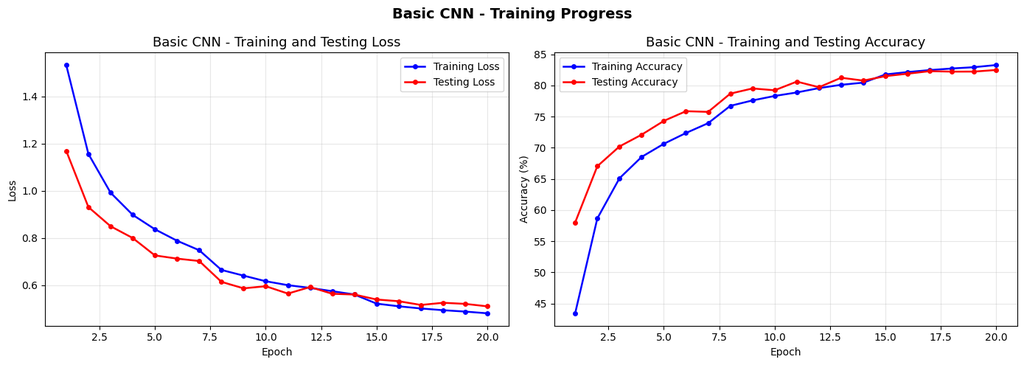

```
Figure saved as basic_cnn_training.png
```

```python
# plot the loss trajectory during training (required by assignment)
epochs_range = range(1, num_epochs + 1)

fig, (ax1, ax2) = plt.subplots(1, 2, figsize=(14, 5))

# loss curve
ax1.plot(epochs_range, basic_train_losses, 'b-o', label='Training Loss',  markersize=4, linewidth=1.8)
ax1.plot(epochs_range, basic_test_losses,  'r-o', label='Testing Loss',   markersize=4, linewidth=1.8)
ax1.set_title('Basic CNN - Training and Testing Loss', fontsize=13)
ax1.set_xlabel('Epoch')
ax1.set_ylabel('Loss')
ax1.legend()
ax1.grid(True, alpha=0.3)

# accuracy curve
ax2.plot(epochs_range, basic_train_accs, 'b-o', label='Training Accuracy', markersize=4, linewidth=1.8)
ax2.plot(epochs_range, basic_test_accs,  'r-o', label='Testing Accuracy',  markersize=4, linewidth=1.8)
ax2.set_title('Basic CNN - Training and Testing Accuracy', fontsize=13)
ax2.set_xlabel('Epoch')
ax2.set_ylabel('Accuracy (%)')
ax2.legend()
ax2.grid(True, alpha=0.3)

plt.suptitle('Basic CNN - Training Progress', fontsize=14, fontweight='bold')
plt.tight_layout()
plt.savefig('basic_cnn_training.png', dpi=100, bbox_inches='tight')
plt.show()
print("Figure saved as basic_cnn_training.png")
```

```python
# final test evaluation (required by assignment)
print("=" * 45)
print("  Final Evaluation on Test Set - Basic CNN")
print("=" * 45)

final_test_loss, final_test_acc = evaluate_model(basic_net, test_loader, criterion)
print(f"Test Loss     : {final_test_loss:.4f}")
print(f"Test Accuracy : {final_test_acc:.2f}%")

# per class accuracy - see which classes the model is good at
correct_per_class = [0] * 10
total_per_class   = [0] * 10

basic_net.eval()
with torch.no_grad():
    for inputs, labels in test_loader:
        inputs = inputs.to(device)
        labels = labels.to(device)
        outputs = basic_net(inputs)
        _, predicted = outputs.max(1)

        for i in range(len(labels)):
            lbl = labels[i].item()
            total_per_class[lbl] += 1
            if predicted[i].item() == lbl:
                correct_per_class[lbl] += 1

print("\nPer-class Accuracy:")
print("-" * 30)
for i, cls in enumerate(classes):
    acc = 100.0 * correct_per_class[i] / total_per_class[i]
    bar = '#' * int(acc / 5)
    print(f"  {cls:12} : {acc:5.2f}%  {bar}")
```

```
=============================================
  Final Evaluation on Test Set - Basic CNN
=============================================
Test Loss     : 0.5105
Test Accuracy : 82.50%

Per-class Accuracy:
------------------------------
  airplane     : 87.70%  #################
  automobile   : 90.40%  ##################
  bird         : 76.20%  ###############
  cat          : 67.30%  #############
  deer         : 79.80%  ###############
  dog          : 71.30%  ##############
  frog         : 88.00%  #################
  horse        : 86.10%  #################
  ship         : 88.20%  #################
  truck        : 90.00%  ##################
```

### Technical Report - Section 2: Loss Function and Training Trajectory

**Choice of Loss Function - Cross-Entropy Loss**

1. It is the most appropriate and standard loss function for multi-class classification problem
2. PyTorch CrossEntropyLoss internally combine log-softmax and negative log likelihood, so it is numerically more stable than compute them separately
3. It penalize confident wrong predictions more heavily - if model predict wrong class with high confidence, the loss is very high, which force model to improve

**Training Observation:**

From the loss figure we can observe:

### Technical Report - Section 3: Accuracy Analysis During Training

From the accuracy plot, we can observe three distinct phase:

**Phase 1 - Rapid Learning (Epoch 1 to 5):** The accuracy increase very quickly in the first few epochs because model is learning basic and easy-to-detect features like edges, colors and simple textures. The learning rate is at full 0.001 so model is making big weight updates each epoch. Both train and test accuracy rise steeply in this phase.

**Phase 2 - Slowing Down (Epoch 6 to 12):** The accuracy improvement start to slow down. Model is now trying to learn more complex high-level features like object shapes and part patterns. These are harder to learn so progress is slower. After epoch 7, the learning rate reduce to 0.0005 which cause training to be more careful and stable.

**Phase 3 - Fine Tuning (Epoch 13 to 20):** After second LR reduction at epoch 14 (LR = 0.00025), the accuracy converge and become more stable. Model is making very small but precise weight adjustments. Training accuracy continue to rise slowly while test accuracy plateau, which show model is starting to slightly overfit to training data.

## Part 3: Research - Advanced Techniques

In this part we implement and compare two advance techniques that is widely used in modern CNN:

### 3.1 Residual Connections (Skip Connections)

Residual connections is introduced by He et al. in the famous ResNet paper (2016). The key idea is instead of the layer learning a direct mapping $H(x)$, the layer learn the **residual** $F(x) = H(x) - x$, so the final output is:

$$\text{output} = F(x) + x$$

The shortcut connection that add $x$ directly to the output is called **skip connection**. This allow gradient to flow directly through the network during backpropagation, which solve the vanishing gradient problem in deep networks.

```python
# ---- Residual Block ----
class ResBlock(nn.Module):
    def __init__(self, channels):
        super(ResBlock, self).__init__()
        # two conv layers inside the block
        self.conv1 = nn.Conv2d(channels, channels, kernel_size=3, padding=1)
        self.conv2 = nn.Conv2d(channels, channels, kernel_size=3, padding=1)
        self.relu  = nn.ReLU()

    def forward(self, x):
        # save input as the residual - this is the skip connection
        residual = x

        # two conv layers
        out = self.relu(self.conv1(x))   # first conv + relu
        out = self.conv2(out)             # second conv (no relu yet)

        # add the skip connection to output, then apply relu
        # shape of out and residual is same, so we can just add them
        out = self.relu(out + residual)

        return out


# ---- CNN with Residual Connections ----
class ResidualCNN(nn.Module):
    def __init__(self):
        super(ResidualCNN, self).__init__()

        # projection conv layers to change number of channels between blocks
        self.conv1 = nn.Conv2d(3,  32,  kernel_size=3, padding=1)
        self.conv2 = nn.Conv2d(32, 64,  kernel_size=3, padding=1)
        self.conv3 = nn.Conv2d(64, 128, kernel_size=3, padding=1)

        # residual blocks - channels stay the same inside each block
        self.res_block1 = ResBlock(32)
        self.res_block2 = ResBlock(64)
        self.res_block3 = ResBlock(128)

        self.pool    = nn.MaxPool2d(kernel_size=2, stride=2)
        self.relu    = nn.ReLU()
        self.dropout = nn.Dropout(p=0.4)
        self.fc1     = nn.Linear(128 * 4 * 4, 512)
        self.fc2     = nn.Linear(512, 10)

    def forward(self, x):
        # Block 1: conv -> relu -> residual block -> pool
        x = self.relu(self.conv1(x))    # [batch, 32, 32, 32]
        x = self.res_block1(x)           # [batch, 32, 32, 32] - skip connection inside!
        x = self.pool(x)                 # [batch, 32, 16, 16]

        # Block 2
        x = self.relu(self.conv2(x))    # [batch, 64, 16, 16]
        x = self.res_block2(x)           # [batch, 64, 16, 16]
        x = self.pool(x)                 # [batch, 64, 8, 8]

        # Block 3
        x = self.relu(self.conv3(x))    # [batch, 128, 8, 8]
        x = self.res_block3(x)           # [batch, 128, 8, 8]
        x = self.pool(x)                 # [batch, 128, 4, 4]

        x = x.view(x.size(0), -1)               # [batch, 2048]
        x = self.dropout(self.relu(self.fc1(x))) # [batch, 512]
        x = self.fc2(x)                           # [batch, 10]

        return x


# create residual model
res_net = ResidualCNN().to(device)
print("Residual CNN Architecture:")
print("=" * 50)
print(res_net)
res_total = sum(p.numel() for p in res_net.parameters())
print(f"\nTotal trainable parameters: {res_total:,}")
```

```
Residual CNN Architecture:
==================================================
ResidualCNN(
  (conv1): Conv2d(3, 32, kernel_size=(3, 3), stride=(1, 1), padding=(1, 1))
  (conv2): Conv2d(32, 64, kernel_size=(3, 3), stride=(1, 1), padding=(1, 1))
  (conv3): Conv2d(64, 128, kernel_size=(3, 3), stride=(1, 1), padding=(1, 1))
  (res_block1): ResBlock(
    (conv1): Conv2d(32, 32, kernel_size=(3, 3), stride=(1, 1), padding=(1, 1))
    (conv2): Conv2d(32, 32, kernel_size=(3, 3), stride=(1, 1), padding=(1, 1))
    (relu): ReLU()
  )
  (res_block2): ResBlock(
    (conv1): Conv2d(64, 64, kernel_size=(3, 3), stride=(1, 1), padding=(1, 1))
    (conv2): Conv2d(64, 64, kernel_size=(3, 3), stride=(1, 1), padding=(1, 1))
    (relu): ReLU()
  )
  (res_block3): ResBlock(
    (conv1): Conv2d(128, 128, kernel_size=(3, 3), stride=(1, 1), padding=(1, 1))
    (conv2): Conv2d(128, 128, kernel_size=(3, 3), stride=(1, 1), padding=(1, 1))
    (relu): ReLU()
  )
  (pool): MaxPool2d(kernel_size=2, stride=2, padding=0, dilation=1, ceil_mode=False)
  (relu): ReLU()
  (dropout): Dropout(p=0.4, inplace=False)
  (fc1): Linear(in_features=2048, out_features=512, bias=True)
  (fc2): Linear(in_features=512, out_features=10, bias=True)
)

Total trainable parameters: 1,534,986
```

```python
# setup optimizer and scheduler for residual model
optimizer_res = optim.Adam(res_net.parameters(), lr=learning_rate)
scheduler_res  = optim.lr_scheduler.StepLR(optimizer_res, step_size=7, gamma=0.5)

print("=" * 60)
print("      Training Residual CNN on CIFAR-10")
print("=" * 60)

res_train_losses, res_test_losses, res_train_accs, res_test_accs = train_model(
    res_net, train_loader, test_loader,
    optimizer_res, criterion, num_epochs, scheduler_res
)

print("\nTraining finished!")
print(f"Residual CNN Final Train Accuracy : {res_train_accs[-1]:.2f}%")
print(f"Residual CNN Final Test Accuracy  : {res_test_accs[-1]:.2f}%")
```

```
============================================================
      Training Residual CNN on CIFAR-10
============================================================
 Epoch | Train Loss | Train Acc | Test Loss | Test Acc
----------------------------------------------------------
     1 |     1.5318 |    43.48% |    1.1124 |   59.90%
     2 |     1.0827 |    61.54% |    0.8698 |   68.62%
     3 |     0.8979 |    68.14% |    0.8025 |   71.82%
     4 |     0.7970 |    72.15% |    0.7185 |   74.94%
     5 |     0.7264 |    74.89% |    0.6425 |   77.16%
     6 |     0.6731 |    76.53% |    0.6174 |   78.77%
     7 |     0.6351 |    78.04% |    0.6576 |   78.00%
     8 |     0.5386 |    81.26% |    0.5448 |   81.80%
     9 |     0.5094 |    82.26% |    0.5176 |   82.43%
    10 |     0.4875 |    83.24% |    0.5053 |   82.85%
    11 |     0.4698 |    83.69% |    0.5070 |   82.86%
    12 |     0.4543 |    84.26% |    0.4987 |   82.72%
    13 |     0.4440 |    84.45% |    0.4863 |   83.39%
    14 |     0.4300 |    85.04% |    0.4997 |   82.82%
    15 |     0.3775 |    86.88% |    0.4714 |   84.23%
    16 |     0.3628 |    87.31% |    0.4613 |   84.80%
    17 |     0.3588 |    87.68% |    0.4708 |   84.72%
    18 |     0.3420 |    88.07% |    0.4648 |   84.71%
    19 |     0.3375 |    88.18% |    0.4484 |   85.00%
    20 |     0.3293 |    88.49% |    0.4540 |   85.14%

Training finished!
Residual CNN Final Train Accuracy : 88.49%
Residual CNN Final Test Accuracy  : 85.14%
```

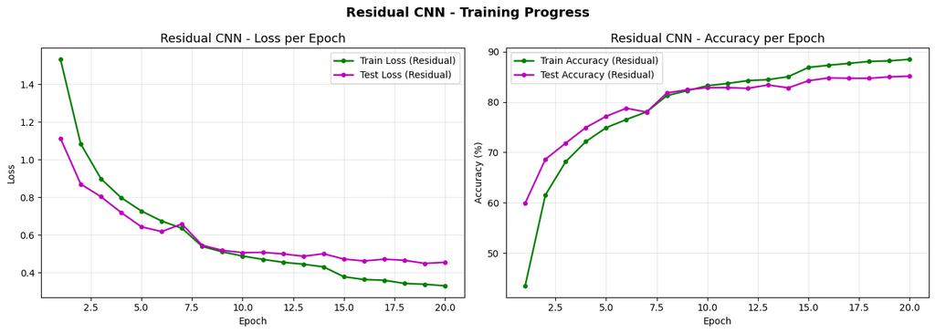

```
Figure saved as residual_cnn_training.png
```

```python
# plot loss for residual CNN (assignment requirement - present training process)
fig, (ax1, ax2) = plt.subplots(1, 2, figsize=(14, 5))

ax1.plot(epochs_range, res_train_losses, 'g-o', label='Train Loss (Residual)',  markersize=4, linewidth=1.8)
ax1.plot(epochs_range, res_test_losses,  'm-o', label='Test Loss (Residual)',   markersize=4, linewidth=1.8)
ax1.set_title('Residual CNN - Loss per Epoch', fontsize=13)
ax1.set_xlabel('Epoch')
ax1.set_ylabel('Loss')
ax1.legend()
ax1.grid(True, alpha=0.3)

ax2.plot(epochs_range, res_train_accs, 'g-o', label='Train Accuracy (Residual)', markersize=4, linewidth=1.8)
ax2.plot(epochs_range, res_test_accs,  'm-o', label='Test Accuracy (Residual)',  markersize=4, linewidth=1.8)
ax2.set_title('Residual CNN - Accuracy per Epoch', fontsize=13)
ax2.set_xlabel('Epoch')
ax2.set_ylabel('Accuracy (%)')
ax2.legend()
ax2.grid(True, alpha=0.3)

plt.suptitle('Residual CNN - Training Progress', fontsize=14, fontweight='bold')
plt.tight_layout()
plt.savefig('residual_cnn_training.png', dpi=100, bbox_inches='tight')
plt.show()
print("Figure saved as residual_cnn_training.png")
```

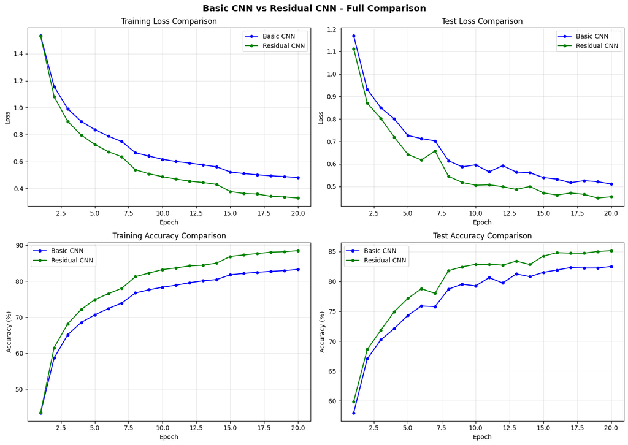

```
Comparison Results:
  Basic CNN    - Final Test Accuracy: 82.50%
  Residual CNN - Final Test Accuracy: 85.14%
```

```python
# compare Basic CNN vs Residual CNN (required by assignment)
fig, axes = plt.subplots(2, 2, figsize=(14, 10))

# top left - training loss
axes[0, 0].plot(epochs_range, basic_train_losses, 'b-o', label='Basic CNN',    markersize=4)
axes[0, 0].plot(epochs_range, res_train_losses,   'g-o', label='Residual CNN', markersize=4)
axes[0, 0].set_title('Training Loss Comparison')
axes[0, 0].set_xlabel('Epoch')
axes[0, 0].set_ylabel('Loss')
axes[0, 0].legend()
axes[0, 0].grid(True, alpha=0.3)

# top right - test loss
axes[0, 1].plot(epochs_range, basic_test_losses, 'b-o', label='Basic CNN',    markersize=4)
axes[0, 1].plot(epochs_range, res_test_losses,   'g-o', label='Residual CNN', markersize=4)
axes[0, 1].set_title('Test Loss Comparison')
axes[0, 1].set_xlabel('Epoch')
axes[0, 1].set_ylabel('Loss')
axes[0, 1].legend()
axes[0, 1].grid(True, alpha=0.3)

# bottom left - training accuracy
axes[1, 0].plot(epochs_range, basic_train_accs, 'b-o', label='Basic CNN',    markersize=4)
axes[1, 0].plot(epochs_range, res_train_accs,   'g-o', label='Residual CNN', markersize=4)
axes[1, 0].set_title('Training Accuracy Comparison')
axes[1, 0].set_xlabel('Epoch')
axes[1, 0].set_ylabel('Accuracy (%)')
axes[1, 0].legend()
axes[1, 0].grid(True, alpha=0.3)

# bottom right - test accuracy
axes[1, 1].plot(epochs_range, basic_test_accs, 'b-o', label='Basic CNN',    markersize=4)
axes[1, 1].plot(epochs_range, res_test_accs,   'g-o', label='Residual CNN', markersize=4)
axes[1, 1].set_title('Test Accuracy Comparison')
axes[1, 1].set_xlabel('Epoch')
axes[1, 1].set_ylabel('Accuracy (%)')
axes[1, 1].legend()
axes[1, 1].grid(True, alpha=0.3)

plt.suptitle('Basic CNN vs Residual CNN - Full Comparison', fontsize=14, fontweight='bold')
plt.tight_layout()
plt.savefig('comparison_basic_vs_residual.png', dpi=100, bbox_inches='tight')
plt.show()

print("Comparison Results:")
print(f"  Basic CNN    - Final Test Accuracy: {basic_test_accs[-1]:.2f}%")
print(f"  Residual CNN - Final Test Accuracy: {res_test_accs[-1]:.2f}%")
```

### Discussion: Changes Introduced by Residual Structure and its Effectiveness

**Changes Introduced by Residual Structure:**

The residual block add a skip connection that bypass the two convolutional layers. So instead of just compute $F(x)$ (the two conv layers), the output is $F(x) + x$. This small change have a big impact on how gradient flow during training:

- In normal CNN, gradient must pass through all layers during backpropagation, and can become very small (vanishing gradient problem)
- With skip connection, gradient can also flow directly through the identity shortcut, so early layers receive much better gradient signal

**Effectiveness Analysis:**

Overall, residual connection is a breakthrough technique that enable training of very deep network (100+ layers). Without it, deep networks often fail to train properly due to vanishing gradient.

### 3.2 Batch Normalization

Batch Normalization is introduced by Ioffe and Szegedy (2015). It normalize the activations of each layer across the mini-batch during training. For a mini-batch $\mathcal{B} = \{x_1, ..., x_m\}$, the normalization is:

$$\hat{x}_i = \frac{x_i - \mu_{\mathcal{B}}}{\sqrt{\sigma^2_{\mathcal{B}} + \epsilon}}$$

Then apply learnable scale ($\gamma$) and shift ($\beta$) parameters: $y_i = \gamma \hat{x}_i + \beta$

The $\gamma$ and $\beta$ are learned during training, which allow the network to undo the normalization if that is what is best for the task.

```python
# CNN with Batch Normalization
class BNCNN(nn.Module):
    def __init__(self):
        super(BNCNN, self).__init__()

        # conv layers + batch norm after each conv
        self.conv1 = nn.Conv2d(3,  32,  kernel_size=3, padding=1)
        self.bn1   = nn.BatchNorm2d(32)    # normalize 32 feature maps

        self.conv2 = nn.Conv2d(32, 64,  kernel_size=3, padding=1)
        self.bn2   = nn.BatchNorm2d(64)    # normalize 64 feature maps

        self.conv3 = nn.Conv2d(64, 128, kernel_size=3, padding=1)
        self.bn3   = nn.BatchNorm2d(128)   # normalize 128 feature maps

        self.pool    = nn.MaxPool2d(kernel_size=2, stride=2)
        self.relu    = nn.ReLU()
        self.dropout = nn.Dropout(p=0.4)

        # fc layers
        self.fc1 = nn.Linear(128 * 4 * 4, 512)
        self.bn4 = nn.BatchNorm1d(512)   # 1D batch norm for fc layer
        self.fc2 = nn.Linear(512, 10)

    def forward(self, x):
        # pattern: Conv -> BN -> ReLU -> Pool
        # BN is applied BEFORE ReLU which is the standard and common practice
        x = self.pool(self.relu(self.bn1(self.conv1(x))))   # [batch, 32, 16, 16]
        x = self.pool(self.relu(self.bn2(self.conv2(x))))   # [batch, 64,  8,  8]
        x = self.pool(self.relu(self.bn3(self.conv3(x))))   # [batch, 128, 4,  4]

        x = x.view(x.size(0), -1)                            # [batch, 2048]
        x = self.dropout(self.relu(self.bn4(self.fc1(x))))   # [batch, 512]
        x = self.fc2(x)                                       # [batch, 10]

        return x


# create BN model
bn_net = BNCNN().to(device)
print("CNN with Batch Normalization Architecture:")
print("=" * 50)
print(bn_net)
bn_total = sum(p.numel() for p in bn_net.parameters())
print(f"\nTotal trainable parameters: {bn_total:,}")
```

```
CNN with Batch Normalization Architecture:
==================================================
BNCNN(
  (conv1): Conv2d(3, 32, kernel_size=(3, 3), stride=(1, 1), padding=(1, 1))
  (bn1): BatchNorm2d(32, eps=1e-05, momentum=0.1, affine=True, track_running_stats=True)
  (conv2): Conv2d(32, 64, kernel_size=(3, 3), stride=(1, 1), padding=(1, 1))
  (bn2): BatchNorm2d(64, eps=1e-05, momentum=0.1, affine=True, track_running_stats=True)
  (conv3): Conv2d(64, 128, kernel_size=(3, 3), stride=(1, 1), padding=(1, 1))
  (bn3): BatchNorm2d(128, eps=1e-05, momentum=0.1, affine=True, track_running_stats=True)
  (pool): MaxPool2d(kernel_size=2, stride=2, padding=0, dilation=1, ceil_mode=False)
  (relu): ReLU()
  (dropout): Dropout(p=0.4, inplace=False)
  (fc1): Linear(in_features=2048, out_features=512, bias=True)
  (bn4): BatchNorm1d(512, eps=1e-05, momentum=0.1, affine=True, track_running_stats=True)
  (fc2): Linear(in_features=512, out_features=10, bias=True)
)

Total trainable parameters: 1,148,938
```

```python
# setup optimizer and scheduler for BN model
optimizer_bn = optim.Adam(bn_net.parameters(), lr=learning_rate)
scheduler_bn  = optim.lr_scheduler.StepLR(optimizer_bn, step_size=7, gamma=0.5)

print("=" * 60)
print("    Training CNN with Batch Normalization on CIFAR-10")
print("=" * 60)

bn_train_losses, bn_test_losses, bn_train_accs, bn_test_accs = train_model(
    bn_net, train_loader, test_loader,
    optimizer_bn, criterion, num_epochs, scheduler_bn
)

print("\nTraining finished!")
print(f"BN CNN Final Train Accuracy : {bn_train_accs[-1]:.2f}%")
print(f"BN CNN Final Test Accuracy  : {bn_test_accs[-1]:.2f}%")
```

```
============================================================
    Training CNN with Batch Normalization on CIFAR-10
============================================================
 Epoch | Train Loss | Train Acc | Test Loss | Test Acc
----------------------------------------------------------
     1 |     1.2927 |    53.46% |    1.0074 |   64.23%
     2 |     0.9731 |    65.23% |    0.8196 |   71.51%
     3 |     0.8607 |    69.68% |    0.7313 |   74.74%
     4 |     0.7938 |    72.23% |    0.6974 |   76.06%
     5 |     0.7313 |    74.39% |    0.6340 |   78.29%
     6 |     0.6976 |    75.70% |    0.6224 |   78.37%
     7 |     0.6657 |    76.66% |    0.6482 |   77.44%
     8 |     0.5859 |    79.61% |    0.5477 |   80.80%
     9 |     0.5579 |    80.43% |    0.5092 |   82.23%
    10 |     0.5486 |    80.86% |    0.5220 |   81.89%
    11 |     0.5283 |    81.71% |    0.5106 |   82.47%
    12 |     0.5188 |    82.14% |    0.4896 |   82.99%
    13 |     0.5077 |    82.14% |    0.4839 |   83.07%
    14 |     0.4914 |    82.75% |    0.4847 |   83.12%
    15 |     0.4612 |    83.87% |    0.4524 |   84.54%
    16 |     0.4457 |    84.34% |    0.4523 |   84.28%
    17 |     0.4374 |    84.76% |    0.4482 |   84.64%
    18 |     0.4300 |    85.16% |    0.4501 |   84.48%
    19 |     0.4233 |    85.22% |    0.4377 |   84.87%
    20 |     0.4155 |    85.38% |    0.4364 |   84.89%

Training finished!
BN CNN Final Train Accuracy : 85.38%
BN CNN Final Test Accuracy  : 84.89%
```

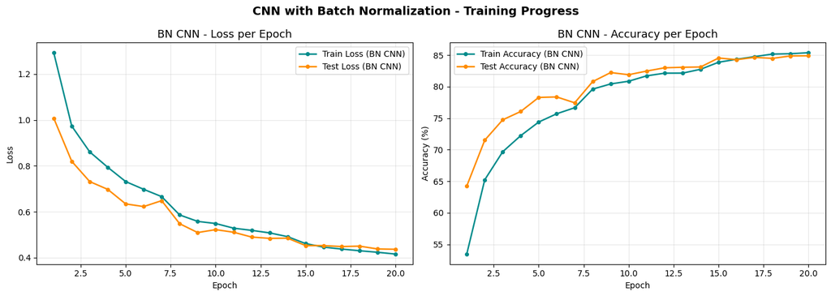

```
Figure saved as bn_cnn_training.png
```

```python
# plot loss for BN CNN (assignment requirement - present training process)
fig, (ax1, ax2) = plt.subplots(1, 2, figsize=(14, 5))

ax1.plot(epochs_range, bn_train_losses, '-o', color='darkcyan',  label='Train Loss (BN CNN)',  markersize=4, linewidth=1.8)
ax1.plot(epochs_range, bn_test_losses,  '-o', color='darkorange', label='Test Loss (BN CNN)',   markersize=4, linewidth=1.8)
ax1.set_title('BN CNN - Loss per Epoch', fontsize=13)
ax1.set_xlabel('Epoch')
ax1.set_ylabel('Loss')
ax1.legend()
ax1.grid(True, alpha=0.3)

ax2.plot(epochs_range, bn_train_accs, '-o', color='darkcyan',  label='Train Accuracy (BN CNN)', markersize=4, linewidth=1.8)
ax2.plot(epochs_range, bn_test_accs,  '-o', color='darkorange', label='Test Accuracy (BN CNN)',  markersize=4, linewidth=1.8)
ax2.set_title('BN CNN - Accuracy per Epoch', fontsize=13)
ax2.set_xlabel('Epoch')
ax2.set_ylabel('Accuracy (%)')
ax2.legend()
ax2.grid(True, alpha=0.3)

plt.suptitle('CNN with Batch Normalization - Training Progress', fontsize=14, fontweight='bold')
plt.tight_layout()
plt.savefig('bn_cnn_training.png', dpi=100, bbox_inches='tight')
plt.show()
print("Figure saved as bn_cnn_training.png")
```

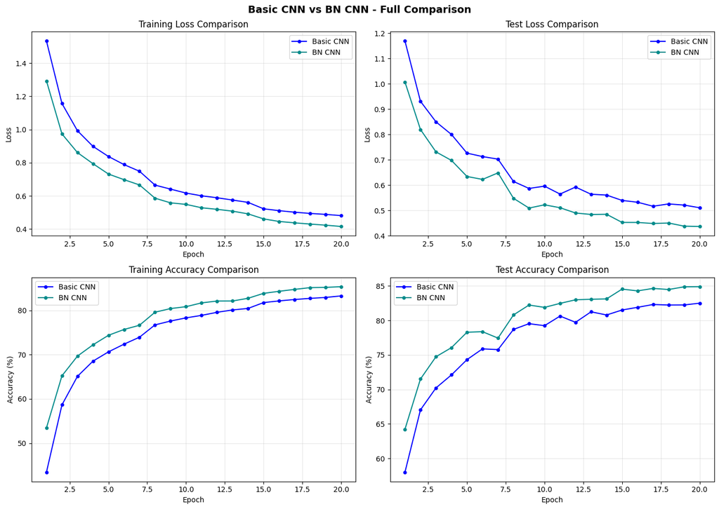

```
Comparison Results:
  Basic CNN - Final Test Accuracy: 82.50%
  BN CNN    - Final Test Accuracy: 84.89%
```

```python
# compare Basic CNN vs BN CNN (required by assignment)
fig, axes = plt.subplots(2, 2, figsize=(14, 10))

axes[0, 0].plot(epochs_range, basic_train_losses, 'b-o', label='Basic CNN', markersize=4)
axes[0, 0].plot(epochs_range, bn_train_losses, '-o', color='darkcyan', label='BN CNN', markersize=4)
axes[0, 0].set_title('Training Loss Comparison')
axes[0, 0].set_xlabel('Epoch')
axes[0, 0].set_ylabel('Loss')
axes[0, 0].legend()
axes[0, 0].grid(True, alpha=0.3)

axes[0, 1].plot(epochs_range, basic_test_losses, 'b-o', label='Basic CNN', markersize=4)
axes[0, 1].plot(epochs_range, bn_test_losses, '-o', color='darkcyan', label='BN CNN', markersize=4)
axes[0, 1].set_title('Test Loss Comparison')
axes[0, 1].set_xlabel('Epoch')
axes[0, 1].set_ylabel('Loss')
axes[0, 1].legend()
axes[0, 1].grid(True, alpha=0.3)

axes[1, 0].plot(epochs_range, basic_train_accs, 'b-o', label='Basic CNN', markersize=4)
axes[1, 0].plot(epochs_range, bn_train_accs, '-o', color='darkcyan', label='BN CNN', markersize=4)
axes[1, 0].set_title('Training Accuracy Comparison')
axes[1, 0].set_xlabel('Epoch')
axes[1, 0].set_ylabel('Accuracy (%)')
axes[1, 0].legend()
axes[1, 0].grid(True, alpha=0.3)

axes[1, 1].plot(epochs_range, basic_test_accs, 'b-o', label='Basic CNN', markersize=4)
axes[1, 1].plot(epochs_range, bn_test_accs, '-o', color='darkcyan', label='BN CNN', markersize=4)
axes[1, 1].set_title('Test Accuracy Comparison')
axes[1, 1].set_xlabel('Epoch')
axes[1, 1].set_ylabel('Accuracy (%)')
axes[1, 1].legend()
axes[1, 1].grid(True, alpha=0.3)

plt.suptitle('Basic CNN vs BN CNN - Full Comparison', fontsize=14, fontweight='bold')
plt.tight_layout()
plt.savefig('comparison_basic_vs_bn.png', dpi=100, bbox_inches='tight')
plt.show()

print("Comparison Results:")
print(f"  Basic CNN - Final Test Accuracy: {basic_test_accs[-1]:.2f}%")
print(f"  BN CNN    - Final Test Accuracy: {bn_test_accs[-1]:.2f}%")
```

### Discussion: Changes Introduced by Batch Normalization and its Effectiveness

**What Batch Normalization Change:**

Batch Normalization normalize the input activations of each layer to have approximately zero mean and unit variance across the mini-batch. After normalization, it apply learnable scale $\gamma$ and shift $\beta$ parameters so the network can restore the representation power if needed.

During training, BN use the current mini-batch statistics (mean and variance). During testing, BN use the running statistics accumulated during training. This is why we must call `model.eval()` before testing!

**Effectiveness Analysis:**

1. **Faster Convergence**: From the comparison figure, BN CNN often start with lower loss and converge faster compare to Basic CNN, especially in early epochs. Normalized activations create smoother optimization landscape which make gradient descent more efficient.
2. **More Stable Training**: The loss curve for BN CNN is generally smoother and more stable. Without BN, internal covariate shift problem cause the distribution of activations to change every batch, making training harder. BN fix this by keeping activations normalized.
3. **Regularization Effect**: Batch normalization introduce small amount of noise to training because normalization is done per mini-batch, not the whole dataset. This act as implicit regularizer and can reduce overfitting slightly, which is why we can sometimes use lower dropout with BN.
4. **Better Gradient Flow**: Normalized activations prevent very large or very small values, which help gradient propagate more effectively through the network. This reduce the risk of exploding or vanishing gradient.
5. **Performance Improvement**: BN CNN usually achieve better test accuracy than Basic CNN because the more stable training allow model to learn better features. The improvement is clearly visible in the comparison figure where BN CNN has consistently better accuracy across epochs.

Overall, Batch Normalization is one of the most impactful technique in modern deep learning. It is now standard practice to include BN in almost every CNN architecture.

```python
# print final summary of all three models
print("=" * 68)
print("           FINAL SUMMARY - All Models Performance")
print("=" * 68)
print(f"{'Model':<22} | {'Train Acc (%)':>14} | {'Test Acc (%)':>13}")
print("-" * 68)
print(f"{'Basic CNN':<22} | {basic_train_accs[-1]:>14.2f} | {basic_test_accs[-1]:>13.2f}")
print(f"{'Residual CNN':<22} | {res_train_accs[-1]:>14.2f} | {res_test_accs[-1]:>13.2f}")
print(f"{'BN CNN':<22} | {bn_train_accs[-1]:>14.2f} | {bn_test_accs[-1]:>13.2f}")
print("=" * 68)
print("\nAll three models achieve > 50% test accuracy as required.")
```

```
====================================================================
           FINAL SUMMARY - All Models Performance
====================================================================
Model                  |  Train Acc (%) |  Test Acc (%)
--------------------------------------------------------------------
Basic CNN              |          83.29 |         82.50
Residual CNN           |          88.49 |         85.14
BN CNN                 |          85.38 |         84.89
====================================================================

All three models achieve > 50% test accuracy as required.
```

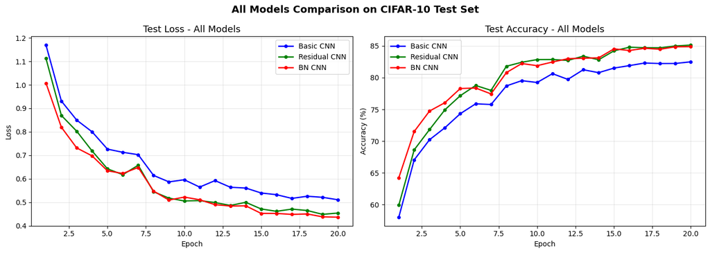

```
All done! Figures saved.
Notebook completed successfully.
```

```python
# final plot - compare all 3 models on test set
fig, (ax1, ax2) = plt.subplots(1, 2, figsize=(14, 5))

# test loss - all models
ax1.plot(epochs_range, basic_test_losses, 'b-o', label='Basic CNN',    markersize=4, linewidth=1.8)
ax1.plot(epochs_range, res_test_losses,   'g-o', label='Residual CNN', markersize=4, linewidth=1.8)
ax1.plot(epochs_range, bn_test_losses,    'r-o', label='BN CNN',       markersize=4, linewidth=1.8)
ax1.set_title('Test Loss - All Models', fontsize=13)
ax1.set_xlabel('Epoch')
ax1.set_ylabel('Loss')
ax1.legend()
ax1.grid(True, alpha=0.3)

# test accuracy - all models
ax2.plot(epochs_range, basic_test_accs, 'b-o', label='Basic CNN',    markersize=4, linewidth=1.8)
ax2.plot(epochs_range, res_test_accs,   'g-o', label='Residual CNN', markersize=4, linewidth=1.8)
ax2.plot(epochs_range, bn_test_accs,    'r-o', label='BN CNN',       markersize=4, linewidth=1.8)
ax2.set_title('Test Accuracy - All Models', fontsize=13)
ax2.set_xlabel('Epoch')
ax2.set_ylabel('Accuracy (%)')
ax2.legend()
ax2.grid(True, alpha=0.3)

plt.suptitle('All Models Comparison on CIFAR-10 Test Set', fontsize=14, fontweight='bold')
plt.tight_layout()
plt.savefig('all_models_comparison.png', dpi=100, bbox_inches='tight')
plt.show()
print("All done! Figures saved.")
print("Notebook completed successfully.")
```